# Who’s in it to Win it?

Pen Jin

2025-04-05

## Introduction

The Olympics are an international sporting event that showcases the athletic abilities of individuals from all over the world. They are held every four years, with the Winter and Summer Olympics being held two years apart from each other.

Some of the questions that we are hoping to answer from this data set are:

Historically, which countries have the tendency to perform well in the Olympics? Using this, how can we predict an athlete’s performance in the next Olympics based on total medal count? What correlations exist between weight, height, and age and the performance outcomes (medal win) of athletes across different sports? Is an athlete’s performance affected by whether their country is the host or not? Does an athlete’s experience and age impact their performance (measured in total medal count per individual)?

This dataset has been acquired from Kaggle. It introduces different individual athletes from the Olympic games in Athens 1896 to Rio in 2016. Information is tracked based on individual performance and information on each athlete, such as the country they represent or their height. https://www.kaggle.com/datasets/heesoo37/120-years-of-olympic-history-athletes-and-results/

| Header | Description | Header | Description |
| --- | --- | --- | --- |
| `id` | Athlete ID | `city` | City of Olympic host |
| `name` | Athlete Name | `sport` | Sport of the Athlete |
| `sex` | Athlete Sex | `event` | Specific event the Athlete is participating in |
| `age` | Athlete Age | `medal` | Medal status of event (Gold, Silver, Bronze, NA) |
| `height` | Athlete Height in cm | `experienced` | If athlete participated in multiple Olympics |
| `weight` | Athlete weight in kg | `total _medal_athlete_olympics` | Total medals per athlete per Olympics |
| `team` | Country/Team the Athlete is competing for | `city_noc` | Olympic host NOC (1980 -2016 Summer) |
| `noc` | NOC region of the Athlete | `host_country` | Athlete from the host NOC or not (1980 -2016 Summer) |
| `games` | Olympic game name | `top_5_ever` | Top 5 medal-earning Country or not (2000 - 2016) |
| `year` | Year of Olympics | `total_events_country_year` | Number of events per NOC |
| `season` | Season of Olympics (winter or summer) | `total_athletes_country_year` | Number of athletes per NOC |

Model 1: age, weight, height, host_country vs. total_medal_athlete_olympics (1980-2016 Summer Olympics) Model 2: age, experienced, and total _medal_athlete_olympics. Model 3: total_athletes_country_year, total_events_country_year, top_5_ever vs. total_medal_athlete_olympics

## Section 2 - Model building

### Section 2.1 - Model 1

```
## # A tibble: 2 × 2
##   host_country     n
##   <chr>        <int>
## 1 no           83727
## 2 yes           4890
```

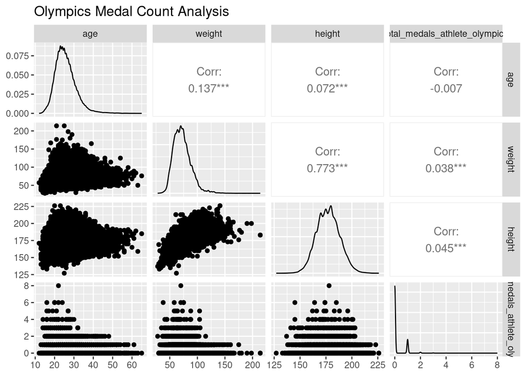

The correlations between medal per athlete per event and age, weight, and height are -0.007, 0.038, and 0.045. All relationships above are weak. The strongest relationship is found between height and medal count per athlete per Olympic which is 0.045 which indicates a positive weak relationship.

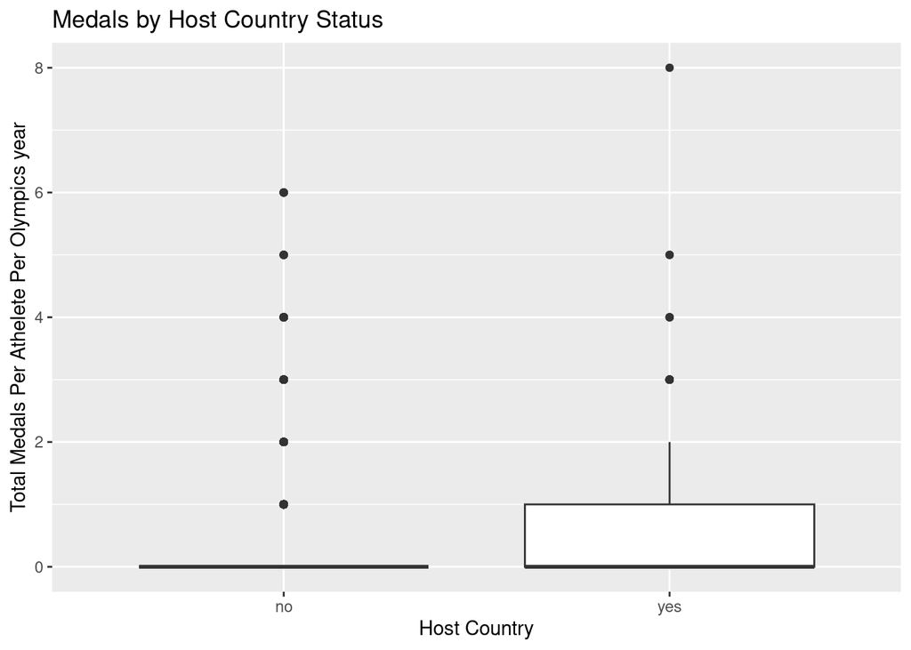

```
## # A tibble: 2 × 2
##   host_country mean_medals
##   <chr>              <dbl>
## 1 no                 0.189
## 2 yes                0.365
```

| Model | Adjusted R square |
| --- | --- |
| `model1a-medal vs age` | 0.0027% |
| `model1b-medal vs height` | 0.1974% |
| `model1c-medal vs weight` | 0.1393% |

| Model | Adjusted R square |
| --- | --- |
| `model2-main effects` | 0.9743% |
| `model3-interaction effects` | 1.0602% |

| Model | RMSE |
| --- | --- |
| model1b-medal vs height | 0.4588 |
| model2-main effects | 0.4576 |
| model3-interaction effect | 0.4573 |

It seems like model3 is the best model with highest rsq of 1.0602% among all models and rmse of 0.4573 which is lower than model1b(height vs medal counts) and model 2 (main effects model).

```
## # A tibble: 8 × 5
##   term                    estimate std.error statistic     p.value
##   <chr>                      <dbl>     <dbl>     <dbl>       <dbl>
## 1 (Intercept)            -0.108     0.0466      -2.32  0.0204
## 2 age                    -0.000391  0.000422    -0.927 0.354
## 3 host_countryyes         0.754     0.199        3.78  0.000154
## 4 height                  0.00159   0.000318     5.01  0.000000540
## 5 weight                  0.000344  0.000223     1.54  0.123
## 6 age:host_countryyes    -0.00911   0.00185     -4.92  0.000000887
## 7 host_countryyes:height -0.00148   0.00140     -1.06  0.288
## 8 host_countryyes:weight -0.00114   0.00104     -1.10  0.271
```

For Non-Host Countries: Total Medals per Athlete per Olympics Hat= −0.108 − 0.00039⋅age + 0.00159⋅height + 0.00034⋅weight

For Host Countries: Total Medals Per Athlete Per Olympics Hat = (−0.108+0.754)+(−0.00039−0.0091)⋅age+(0.00159−0.00148)⋅height+(0.00034−0.00114)⋅weight = 0.646 − 0.00949⋅age + 0.00011⋅height − 0.00080⋅weight

Intercept: For non-host countries, the intercept is -0.108. For host countries, the intercept increases by 0.754, making it 0.646. This indicates that athletes from host countries are predicted to earn 0.754 more medals compared to non-host countries, holding all other variables constant.

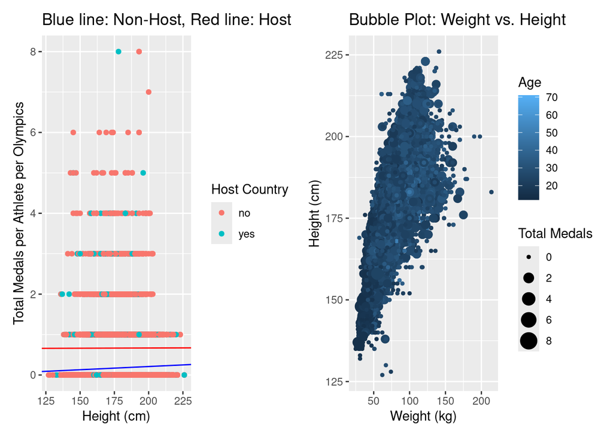

Conclusion with Data Insights:

Host Country Effect: On average, athletes from host countries won 0.3651 medals per Olympics, while those from non-host countries won 0.1888 medals per Olympics, showing a significant host advantage.

Height: Height positively influences medal count, but the effect is minimal. For non-host countries, an increase of 1 cm in height predicts an increase of 0.00159 medals. For host countries, the effect slightly decreases to 0.00011 medals per cm.

Summary: While host country status is the most influential factor, the effects of age, weight, and height are minor. Athletes from host countries consistently outperform their non-host peers across all variables. This highlights the significant contextual advantage of competing as a host athlete.

### Section 2.2 - Model 2

```
## # A tibble: 44,309 × 22
##       id name     sex     age height weight team  noc   games  year season city
##    <dbl> <chr>    <chr> <dbl>  <dbl>  <dbl> <chr> <chr> <chr> <dbl> <chr>  <chr>
##  1     2 A Lamusi M        23    170     60 China CHN   2012…  2012 Summer Lond…
##  2    18 Timo An… M        31    189    130 Finl… FIN   2000…  2000 Summer Sydn…
##  3    22 Andreea… F        22    170    125 Roma… ROU   2016…  2016 Summer Rio …
##  4    23 Fritz A… M        26    187     89 Norw… NOR   2004…  2004 Summer Athi…
##  5    33 Mika La… M        24    187     76 Finl… FIN   1992…  1992 Summer Barc…
##  6    36 Stefan … M        25    194     78 Neth… NED   2000…  2000 Summer Sydn…
##  7    37 Ann Kri… F        23    182     64 Norw… NOR   1996…  1996 Summer Atla…
##  8    49 Moonika… F        24    168     65 Esto… EST   2004…  2004 Summer Athi…
##  9    50 Arvi Aa… M        22    185    106 Esto… EST   1992…  1992 Summer Barc…
## 10    53 Talaat … M        24    172     58 Egypt EGY   2000…  2000 Summer Sydn…
## # ℹ 44,299 more rows
## # ℹ 10 more variables: sport <chr>, event <chr>, medal <chr>,
## #   experienced <chr>, total_medals_athlete_olympics <int>, city_noc <chr>,
## #   host_country <chr>, top_5_ever <chr>, total_events_country_year <int>,
## #   total_athletes_country_year <int>
```

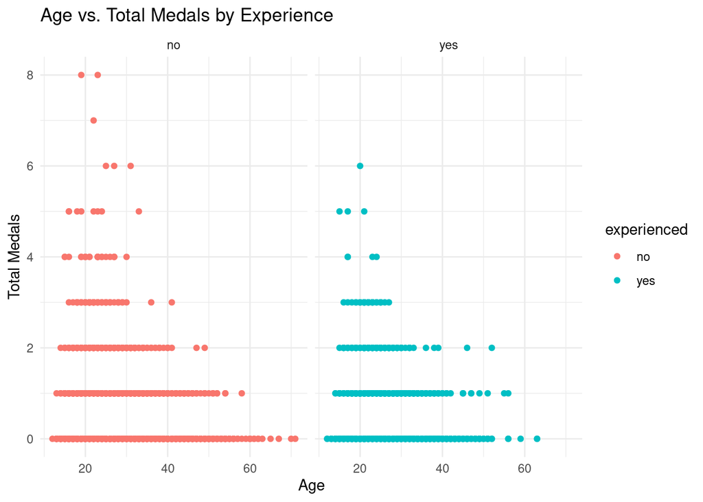

Next, we will build models off of the variables.

```
## Model 1a Adjusted R-squared: 0.0196 %
```

```
## Model 1b Adjusted R-squared: 0.0091 %
```

```
##
## Call:
## lm(formula = total_medals_athlete_olympics ~ age * experienced,
##     data = olympics_test_filtered)
##
## Residuals:
##     Min      1Q  Median      3Q     Max
## -0.2643 -0.1972 -0.1958 -0.1924  7.8036
##
## Coefficients:
##                      Estimate Std. Error t value Pr(>|t|)
## (Intercept)         0.2028059  0.0123265  16.453  < 2e-16 ***
## age                -0.0002783  0.0004698  -0.592    0.554
## experiencedyes      0.1122159  0.0245563   4.570 4.90e-06 ***
## age:experiencedyes -0.0039517  0.0009380  -4.213 2.53e-05 ***
## ---
## Signif. codes:  0 '***' 0.001 '**' 0.01 '*' 0.05 '.' 0.1 ' ' 1
##
## Residual standard error: 0.4593 on 44305 degrees of freedom
## Multiple R-squared:  0.0007335,  Adjusted R-squared:  0.0006658
## F-statistic: 10.84 on 3 and 44305 DF,  p-value: 4.089e-07
```

```
## RMSE for Model 1a (age): 0.4594
```

```
## RMSE for Model 1b (experience): 0.4594
```

```
## RMSE for Model 3 (main effects + interactions): 0.4593
```

```
## # A tibble: 3 × 3
##   Model                                `Adjusted R-squared (%)`  RMSE
##   <chr>                                                   <dbl> <dbl>
## 1 Model 1a (age)                                         0.0196 0.459
## 2 Model 1b (experience)                                  0.0091 0.459
## 3 Model 3 (main effects + interaction)                   0.0666 0.459
```

Model 3 is the best model overall, as it has the lowest RMSE and the highest Adjusted R-squared.

```
## # A tibble: 4 × 5
##   term                estimate std.error statistic  p.value
##   <chr>                  <dbl>     <dbl>     <dbl>    <dbl>
## 1 (Intercept)         0.203     0.0123      16.5   1.21e-60
## 2 age                -0.000278  0.000470    -0.592 5.54e- 1
## 3 experiencedyes      0.112     0.0246       4.57  4.90e- 6
## 4 age:experiencedyes -0.00395   0.000938    -4.21  2.53e- 5
```

For non-experienced athletes: Total Medals = 0.2028 − 0.000278 × age

For experienced athletes: Total Medals = 0.3150 − 0.004228 × age

Summary:

Non-Experienced Athletes: The baseline predicted total_medals is 0.2028. For each year of age, the predicted total_medals decreases by 0.000278.

Experienced Athletes: The baseline predicted total_medals for experienced athletes is higher (0.2028 + 0.1122 = 0.3150) compared to non-experienced athletes. The effect of age on total_medals is different for experienced athletes, as indicated by the significant interaction term.

Data Insights:

### Section 2.3 - Model 3

This model examines how a country’s success and participation in the Olympics influence the number of medals earned by its athletes. By focusing on country-level factors such as the total number of athletes, number of events participated in, and whether the country is among the top 5 in medal earnings, this model seeks to explore the systemic factors that contribute to an athlete’s success.

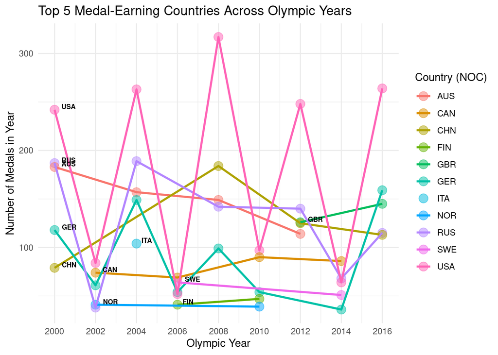

This color-connected scatter plot visualizes the performance of the top 5 competing countries in each Olympics from 2000 to 2016. By color-coding each country, the plot highlights how certain nations consistently remain at the top over time. This plot demonstrates the historical trend where some countries consistently score higher in total medal counts, offering a comparison of how a country’s historical performance might influence the success of its athletes.

```
## # A tibble: 11 × 2
##    noc   top_5_count
##    <chr>       <int>
##  1 AUS             4
##  2 CAN             4
##  3 CHN             4
##  4 FIN             2
##  5 GBR             2
##  6 GER             8
##  7 ITA             1
##  8 NOR             2
##  9 RUS             7
## 10 SWE             2
## 11 USA             9
```

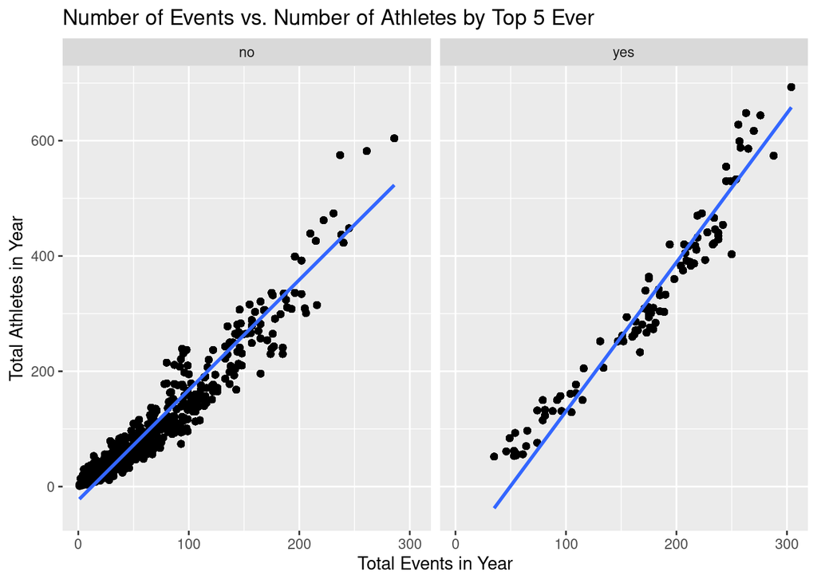

The facet-wrap in the scatter plot allows for the visualization of relationships between the number of events and the number of athletes in different groups, categorized by whether a country is in the top 5 medal earners historically. The facet for top_5_ever = no shows most of its points clustered towards the bottom left, indicating that countries not historically in the top 5 medal earners tend to have lower numbers of events and athletes. This suggests these countries may have smaller delegations or participate in fewer events, which could limit their overall performance. In contrast, the facet for top_5_ever = yes displays points more evenly distributed along the line, implying that countries in the top 5 medal earners generally exhibit a more consistent or proportionate relationship between the number of athletes and events. These countries likely have larger delegations and participate in a broader range of events, which may contribute to their sustained success in the Olympics. Overall, this pattern suggests that top-performing countries have a stronger and more balanced connection between their athlete participation and event engagement, whereas non-top-performing countries tend to have fewer athletes and events, potentially limiting their chances of winning medals.

To further investigate the relationship, here are linear models of each explanatory variable:

```
## # A tibble: 2 × 5
##   term                      estimate std.error statistic  p.value
##   <chr>                        <dbl>     <dbl>     <dbl>    <dbl>
## 1 (Intercept)                0.0362  0.00408        8.86 8.13e-19
## 2 total_events_country_year  0.00123 0.0000264     46.7  0
```

```
## # A tibble: 2 × 5
##   term                        estimate std.error statistic  p.value
##   <chr>                          <dbl>     <dbl>     <dbl>    <dbl>
## 1 (Intercept)                 0.0529   0.00357        14.8 1.22e-49
## 2 total_athletes_country_year 0.000608 0.0000120      50.9 0
```

```
## # A tibble: 2 × 5
##   term          estimate std.error statistic   p.value
##   <chr>            <dbl>     <dbl>     <dbl>     <dbl>
## 1 (Intercept)      0.159   0.00264      60.2 0
## 2 top_5_everyes    0.123   0.00462      26.7 2.77e-155
```

```
## # A tibble: 4 × 5
##   term                        estimate std.error statistic   p.value
##   <chr>                          <dbl>     <dbl>     <dbl>     <dbl>
## 1 (Intercept)                  0.0778  0.00459       17.0  2.08e- 64
## 2 total_events_country_year   -0.00106 0.000108      -9.77 1.52e- 22
## 3 total_athletes_country_year  0.00114 0.0000498     22.8  1.81e-114
## 4 top_5_everyes               -0.0354  0.00586       -6.04 1.52e-  9
```

Equations:

| Model | Adjusted R square | RMSE |
| --- | --- | --- |
| modela-medal vs events | 4.691% | 0.449 |
| modelb-medal vs athletes | 5.518% | 0.447 |
| modelc-medal vs top5 | 1.576% | 0.456 |
| modeld-medal vs combined | 5.81% | 0.446 |

Based on statistical significance, adjusted rsq, and low RMSE score, the Combined Model is the best fit for this Model. It has the highest rsq percentage of 5.81% and an RMSE of 0.446. While single-variable models provide certain insights, the main effects (“combined”) model better accounts for the multi-faceted factors influencing an athlete’s medal performance.

Data Insights: Top 5 Ever Status: Countries historically in the top 5 tend to have lower total medals per athlete compared to countries outside the top 5. This suggests that historical success may come with higher competition, potentially spreading out the medal count across more athletes.

Number of Athletes: The number of athletes from a noc has a positive effect on the total medals per athlete. This indicates that having more athletes in the Olympics correlates with a higher likelihood of winning more medals per athlete, likely due to the increased chances of success from a larger pool of competitors.

Number of Events: The number of events a country participates in has a negative relationship with medals per athlete. This may indicate that as countries participate in more events, the distribution of medals may become more diluted, resulting in fewer medals per athlete overall.

Summary: The factors influencing medal count of this model include the number of athletes per country, the number of events per country, and historical performance (Top 5 Ever status). Countries with a higher number of athletes perform better overall, while those in countries that have been top 5 tend to see fewer medals per athlete, possibly due to greater competition. The effect of the number of events suggests that increased competition from more events can dilute medal outcomes.

## Section 3 - Results

Equation if Country was in the Top 5: Total_Medals_Athlete_Hat= 0.142−0.00126 * Total Events Country Year+0.00112 * Total Athletes Country Year + 0.0802  
Equation if Country was not in the Top 5: Total_Medals_Athlete_Hat= 0.142−0.00126 * Total Events Country Year+0.00112 * Total Athletes Country Year

Intercept: If a country has 0 total events and 0 total athletes in a given year and is not in the top 5 historically, the model predicts that the country will win approximately 0.142 medals per athlete per Olympics.

Slope: For each additional event held per country per year, the model predicts a decrease of 0.00126 medals per athlete per Olympics. For each additional athlete in a country per year, the model predicts an increase of 0.00112 medals per athlete per Olympics. If a country is in the top 5 historically (Top 5 Ever = 1), the model predicts an increase of 0.0802 medals per athlete per Olympics compared to countries that are not in the top 5.

```
## # A tibble: 4 × 5
##   term                        estimate std.error statistic   p.value
##   <chr>                          <dbl>     <dbl>     <dbl>     <dbl>
## 1 (Intercept)                  0.142   0.00221        64.1 0
## 2 total_events_country_year   -0.00126 0.0000378     -33.4 9.84e-245
## 3 total_athletes_country_year  0.00112 0.0000169      66.1 0
## 4 top_5_everyes                0.0802  0.00276        29.0 9.53e-185
```

| Final Model | Adjusted R square | RMSE |
| --- | --- | --- |
| modeld-medal vs combined | 4.189% | 0.621 |

Conclusion with Data Insights: Our model shows that total events, total athletes, and historical top 5 status significantly influence an Athlete’s Olympic medal performance. The final model “modeld-medal vs combined” with an Adjusted R square of 4.189% and RMSE of 0.621 performs worse compared to the Olympics training data model, which has a higher Adjusted R square of 5.81% and a lower RMSE of 0.446. This is to be expected when dealing with a larger dataset, as larger datasets often introduce more complexity and variability, which can lead to a decrease in model performance.While the number of events negatively correlates with medals, suggesting that fewer events may lead to better focus and performance, the number of athletes has a positive relationship with medal count. This could mean that a larger team offers more opportunities for success. Historical top 5 status strongly predicts higher medal counts, emphasizing the role of established infrastructure and experience in guiding the success of an Athlete.

## Bibliography

“Olympedia .” Www.olympedia.org, Sports Reference, www.olympedia.org/. Accessed May 2018.

Moore, Andrew. “NC State Experts Weigh in on the Importance of the Olympics.” College of Natural Resources News, 2024, cnr.ncsu.edu/news/2024/08/why-the-olympics-are-important/.